# Lab 8 - Linear Regressions

## Exercise 4

#### Question

Using plot_ss, choose a line that does a good job of minimizing the sum of squares. Run the function several times. What was the smallest sum of squares that you got? How does it compare to your neighbors?

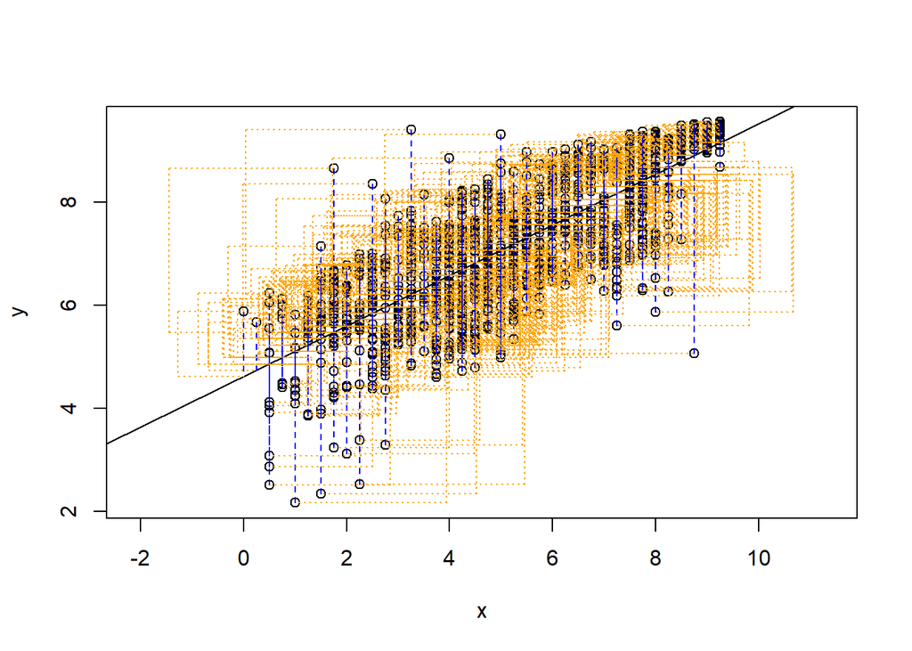

```
## Click two points to make a line.

## Call:
## lm(formula = y ~ x, data = pts)
##
## Coefficients:
## (Intercept)            x
##      4.6171       0.4914
##
## Sum of Squares:  952.153
```

```r
hfi_clean <- hfi %>% filter(!is.na(pf_score))

DATA606::plot_ss(x = hfi_clean$pf_expression_control,
                 y = hfi_clean$pf_score,
                 showSquares = TRUE)
```

#### Response

The lowest sum of squares I got when manually choosing two points was ~5068, with ann intercept of 4.9872 and a $\beta$ of 0.4861. As indicated above, however, the true minimized sum of squares with the best fit line is much lower.

## Exercise 5

#### Question

Fit a new model that uses pf_expression_control to predict hf_score, or the total human freedom score. Using the estimates from the R output, write the equation of the regression line. What does the slope tell us in the context of the relationship between human freedom and the amount of political pressure on media content?

#### Response

```r
model_fit <- lm(hf_score ~ pf_expression_control, data = hfi)

summary(model_fit)
```

```
##
## Call:
## lm(formula = hf_score ~ pf_expression_control, data = hfi)
##
## Residuals:
##     Min      1Q  Median      3Q     Max
## -2.6198 -0.4908  0.1031  0.4703  2.2933
##
## Coefficients:
##                       Estimate Std. Error t value Pr(>|t|)
## (Intercept)           5.153687   0.046070  111.87   <2e-16 ***
## pf_expression_control 0.349862   0.008067   43.37   <2e-16 ***
## ---
## Signif. codes:  0 '***' 0.001 '**' 0.01 '*' 0.05 '.' 0.1 ' ' 1
##
## Residual standard error: 0.667 on 1376 degrees of freedom
##   (80 observations deleted due to missingness)
## Multiple R-squared:  0.5775, Adjusted R-squared:  0.5772
## F-statistic:  1881 on 1 and 1376 DF,  p-value: < 2.2e-16
```

The positive slope indicates a positive correlation between `pf_expression_control` and `hf_score`. In other words, as `pf_expression_control` increases, so does `hf_score`. So, countries with less political pressure on media content tend to have high total human freedom scores.